# Reanalysis project

May Dixon

November 5, 2016

## Reanalysis of: Antiphonal calling allows individual discrimination in white-winged vampire bats

#### Carter, G. G., Skowronski, M. D., Faure, P. A., and Fenton, B. 2008 Animal Behaviour. 76:4, 1343-1355

#### Study background / goal of paper

This study investigated the function of social calls in white-winged vampire bats. Bat social calls have complex acoustic structures which are capable of carrying a lot of information, as well as inter-individual variation that could contribute in individual recognition. The function of these calls in white-winged vampire bats, a highly social species, was unknown. This study tested several aspects of these social calls in several experiments: 1) whether calls elicit antiphonal responses,2) whether there is consistent individual variation in call structure, and 3) whether bats discriminate between the calls of individuals. For my analysis I am going to look at the **third** component, individual discimination.

#### The habituation-discrimination test

The authors used a habituation-discrimination (also called habituation-dishabituation) paradigm for this task. This paradigm is widely used in psychology, and is a powerful tool for testing individual discrimination, not least because it requires no training. The basic test is as follows: **The goal is to test whether animals discriminate between any two stimuli** (say “stim A” and “stim B”). You present an animal repeatedly with stim A until the animal habituates to it, as demonstrated by a decline in response to the stimulus. Then, you change the stimulus to stim B. If it does not discriminate, then it will continue its habituated response. However, since habituation is stimulus specific, if an animal discriminates between stim A and stim B, then it will not be habituated to stim B, and it will respond to it at the initial level. You may be able to detect a difference in th rate of response. If the animal has a low baseline response level to stim B, though, there may be no difference between that and the habituated response to A, which could erroneously lead you to conclude that there was no discrimination. You can overcome this by presenting the first stimulus again. If the animal discriminated between stim A and B, then hearing stim B should have dishabituated the animal to stim A. If you offer stim A again, it should respond to it more than it did at the end of habituation.

#### Experimental methods

So, the authors investigated whether bats discriminated between the social calls of different individuals. To do this, they put bats alone in a small enclosure. They respeatedly presented social calls from one individual bats, for 30 to 90 seconds, then changed the stimulus to the social call of another individual for 10 seconds, and finally presented the first stimulus for 10 more seconds. They measured 2 general responses 1) The number of antiphonal vocal calls produced in response to each experimental call, and 2) physical responses to each call, including either physical orientation towards the speaker, or startling from an eyes-closed position in response to the call.

The experimenters organized the data in two ways, by pooling mean reponses to the stimuli by bat, and by pooling mean responses of all the bats to each sequence. Each bat received a number of different trials with different experimental sequences, so the experimenters reported the mean responses by bat. Each stimulus sequence was also used more than once, so they also analyzed the data by sequence.These two different levels dive you different degrees of freedom (7 d.f. in the former and 15 in the latter). (I don’t have the data for this, but you could analyze the relative amount of ‘random’ variation explained by sequence and by bat to see which is a more logical grouping factor).

These are the column names, and what they mean:

For the ‘by bat’ data:

```r
> # import bat data
> gc_bat <- read.delim("https://raw.githubusercontent.com/maydixon/reanalysis_project_ada2016/master/gc_data_by_bat.txt",
+     header = TRUE, sep = "\t")
> head(gc_bat)
```

```
##     subject vocal.first vocal.mid vocal.last vocal.test vocal.post
## 1   daniela        0.75         0          0       6.00       0.59
## 2    farouk        0.71         0          0       3.04       0.00
## 3 hermanson        0.25         0          0       0.19       0.00
## 4     isaac        0.00         0          0       0.00       0.00
## 5 jerrywilk        0.00         0          0       0.50       0.50
## 6      punk        0.50         0          0       1.25       0.00
##   vocal.last.post visual.first visual.mid visual.last visual.test
## 1           0.295         1.84       1.12        0.63        1.47
## 2           0.000         1.79       0.29        1.79        5.64
## 3           0.000         1.33       0.00        0.75        2.79
## 4           0.000         1.50       0.10        0.00        1.50
## 5           0.250         3.50       5.00        3.50        4.50
## 6           0.000         0.00       0.10        1.25        1.25
##   visual.post visual.last.post
## 1        0.58            0.605
## 2        1.71            1.750
## 3        1.33            1.040
## 4        0.00            0.000
## 5        4.75            4.125
## 6        1.25            1.250
```

For the ‘by sequence’ data:

```r
> # import sequence data
> gc_seq <- read.delim("https://raw.githubusercontent.com/maydixon/reanalysis_project_ada2016/master/gc_data_by_sequence.txt",
+     header = TRUE, sep = "\t")
> head(gc_seq)
```

```
##   playback.sequence N.subjects vocal.first vocal.mid vocal.last vocal.test
## 1               a-d          2       0.000         0      0.000      0.000
## 2               a-l          1       0.000         0      0.000     10.000
## 3               a-r          5       1.532         0      0.866     10.132
## 4               b-k          2       0.500         0      0.000      0.000
## 5               b-l          2       4.000         0      0.000     14.000
## 6               b-r          3       0.666         0      0.000      5.333
##   vocal.post visual.first visual.mid visual.last visual.test visual.post
## 1      0.000         0.00      0.000       0.000        0.00       0.000
## 2      0.000         0.00      0.000       0.000        3.50       2.000
## 3      4.982         0.75      0.285       1.400        2.95       1.857
## 4      0.000         0.00      0.000       0.000        0.50       0.500
## 5      0.000         5.00      0.500       0.000        8.50       0.250
## 6      8.000         2.00      1.333       1.333        4.00       1.833
```

Basic column names (these are from the data pooled by bat, but columns are named similarly for the data pooled by sequence) :

```
##  [1] "subject"          "vocal.first"      "vocal.mid"
##  [4] "vocal.last"       "vocal.test"       "vocal.post"
##  [7] "vocal.last.post"  "visual.first"     "visual.mid"
## [10] "visual.last"      "visual.test"      "visual.post"
## [13] "visual.last.post"
```

subject = bat ID  
vocal.first = the average number of calls the bat made in the first 10 seconds of habituation  
vocal.mid = the average number of calls the bat made in the middle 10 seconds of habituation  
vocal.last = the average number of calls the bat made in the final 10 seconds of habituation  
vocal.test = the average number of calls made during the 10 seconds of the new stimulus  
vocal.post = the average number of calls in the first 10 seconds when the first stimulus returned  
vocal.last.post = the average number of calls in the last 10 seconds when the first stimulus returned  
visual.first = the average number of physical responses the bat made in the first 10 seconds of habituation  
visual.mid = the average number of physical responses the bat made in the middle 10 seconds of habituation  
visual.last = the average number of physical responses the bat made in the final 10 seconds of habituation  
visual.test = the average number of physical responses made during the 10 seconds of the new stimulus  
visual.post = the average number of physical responses in the first 10 seconds when the first stimulus returned  
visual.last.post = the averaged number of physical responses for visual.last and visual.post

#### Description of analyses run by Carter et al.

Carter et al. must have determined that the data were decidedly non-normal, because they used non-parametric tests. They used Wilcoxon signed-rank tests to test whether the vocal and physical response to Stim A 10 before and after Stim B were significantly greater than the responses during Stim B. They repeated this analysis with the sequences as the base unit and with the bat subjects as the base unit. They also used a Wilcoxon signed-rank test to see whether the initial responses to Stim A were significantly different than the initial responses to Stim B (though all stimulus sequences were used as both Stim A and Stim B)

#### Description of reanalysis run by me:

I tested for normality, and ran all the Wilcoxon tests run by Carter et al. I also ran the Wilcoxon test for discrimination slightly differently, comparing only the response to the last 10s of Stim A to the response to Stim B. I also ran a Friedman test to see whether bats actually did habituate to Stim A. All the tests for the bat-level data are shown, and then are repeated for the sequence level data underneath.

### Analyses of Bat-level data:

#### Exploratory stats

Are these data appropriate for parametric stats?

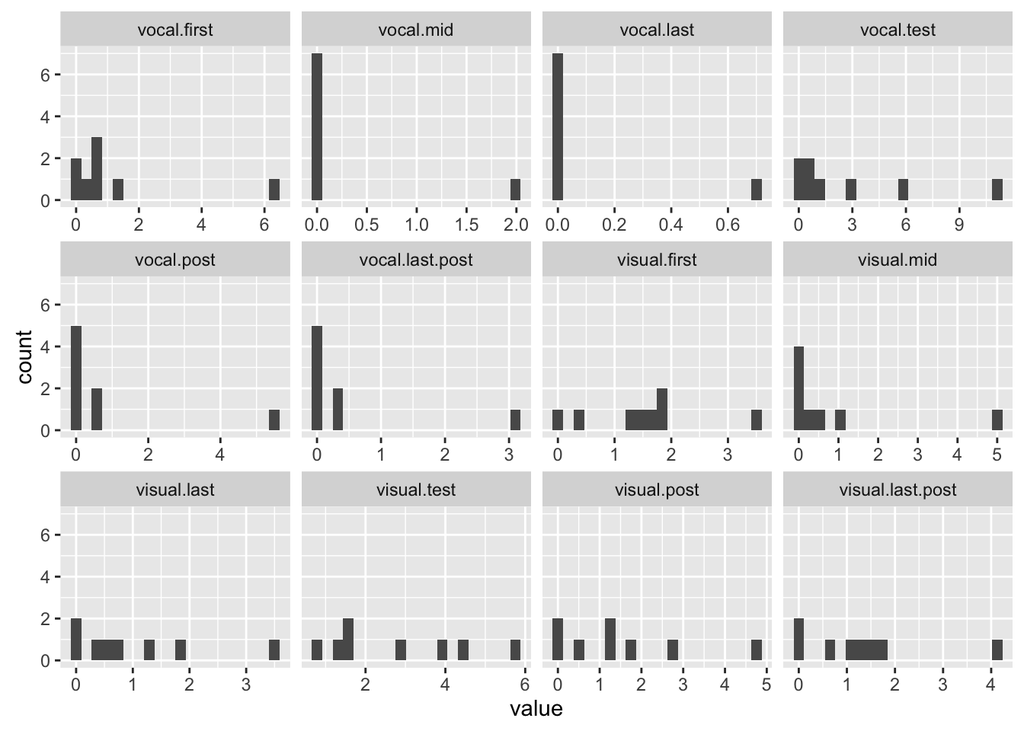

So, it seems clear from the histograms that there are too few cases, and that they are no where near enough to normal, to use parametric statistics.

This bat, “Kristina”, is also a bit of an outlier:

```
##    subject vocal.first vocal.mid vocal.last vocal.test vocal.post
## 8 kristina        6.32      1.99        0.7      11.11        5.5
##   vocal.last.post visual.first visual.mid visual.last visual.test
## 8             3.1         1.74        0.5       0.367        3.81
##   visual.post visual.last.post
## 8        2.83           1.5985
```

As long as I am already using rank-based non-parametric stats, I am going to leave her in.

### Now let’s visualize how bats responded to these treatments:

#### Visualizing the vocal response data

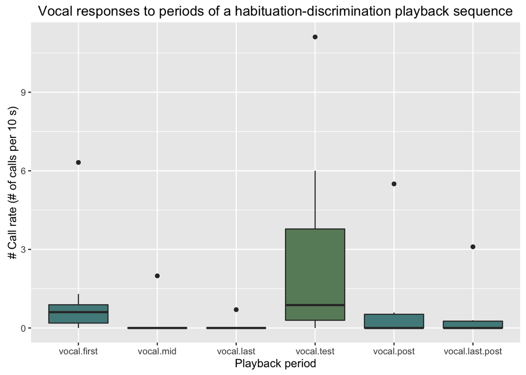

The columns are colored by the part of the test. The dark teal columns are all responses to the habituating part of the stimulus (Stim A), and the green column is the responses to the test stimulus (Stim B)

#### Visualizing the visual response data:

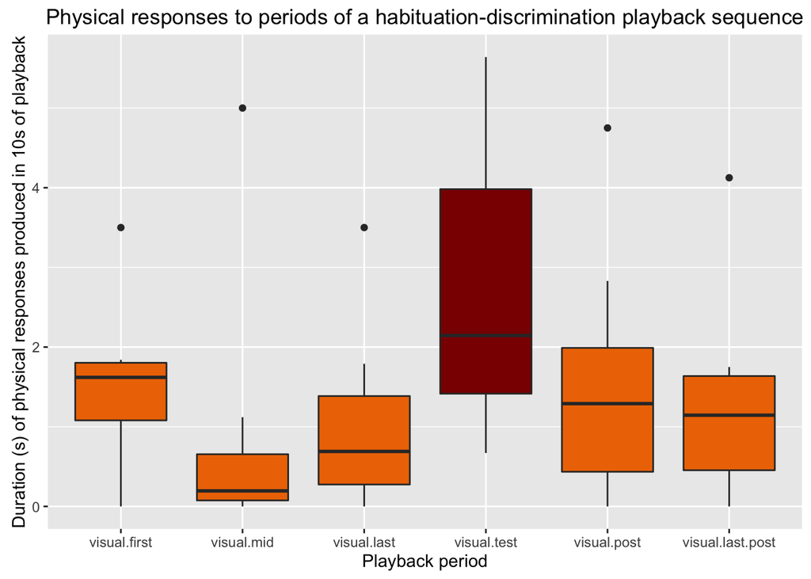

This is the corresponding chart in Carter et al. (I used a box chart rather than a bar chart because I think they are more informative) :

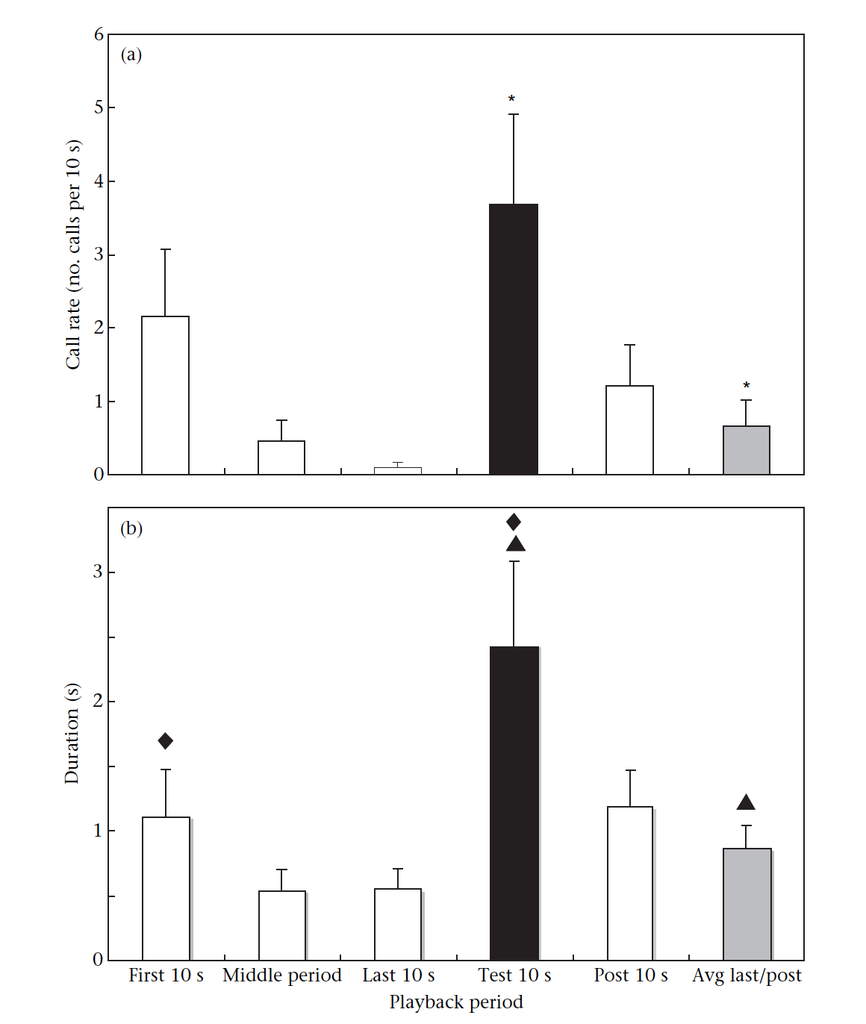

##### Carter et al. Averaged the responses for 10s right before and right after the test calls, and compared that to the response during the test calls (last column of chart). This is a conservative approach (see text). This is what this looks like, using non-parametric stats: wilcoxon-signed rank test (because variables are not independent, but rather matched):

The tests are **one-tailed**, because we are always testing the hypothesis that the response to the test call is **greater**, and are **paired**, as all bats recived each treatment.

The bat level vocal response:

The median vocal response to the test calls:

```
## [1] 0.875
```

The median vocal response to the calls before and after the test response:

```
## [1] 0
```

```
##
##  Wilcoxon signed rank test with continuity correction
##
## data:  gc_bat$vocal.test and gc_bat$habit_avg_voc
## V = 28, p-value = 0.01125
## alternative hypothesis: true location shift is greater than 0
```

The bat level visual response:

The median visual response to the calls during the test response:

```
## [1] 2.145
```

The median visual response to the calls before and after the test response:

```
## [1] 0.5090275
```

```
##
##  Wilcoxon signed rank test
##
## data:  gc_bat$visual.test and gc_bat$habit_avg_vis
## V = 29, p-value = 0.07422
## alternative hypothesis: true location shift is greater than 0
```

It is unclear why these values are different– they aren’t more similar when run unpaired, two.tailed, or in any other configuration thereof. The visual response P-value is slightly above the 0.05 alpha, but it is hard to understand this, because it looks clearly different in the graph.

##### Initial responses to Stim A and Stim B

median initial visual response to Stim A

```
## [1] 1.62
```

median initial visual response to Stim B

```
## [1] 2.145
```

Wilcoxon Test for visual reponses. I’m running this two-sided, because I don’t have initial assumptions about which response should be larger

```
##
##  Wilcoxon signed rank test with continuity correction
##
## data:  gc_bat$visual.first and gc_bat$visual.test
## V = 2, p-value = 0.05191
## alternative hypothesis: true location shift is not equal to 0
```

median initial vocal response to Stim A

```
## [1] 0.605
```

median initial vocal response to Stim B

```
## [1] 0.875
```

Wilcoxon Test for vocal reponses. I’m running this two-sided, because I don’t have initial assumptions about which response should be larger

```
##
##  Wilcoxon signed rank test with continuity correction
##
## data:  gc_bat$vocal.first and gc_bat$vocal.test
## V = 5, p-value = 0.1508
## alternative hypothesis: true location shift is not equal to 0
```

This visual Wilcoxin test returned V = 2, p-value = 0.05191 (Carter et al. found p=0.047). So, while our value is skimming above the alpha of 0.05, it is likely that the bats responded more to the second sequence than they did to the first stimulus initially. (There was no difference found in the vocal responses (p=0.1508), unreported in Carter et al.) This difference must be due to the experimental design, rather than something fundamental to the particular sequences used, because the same sequences (n=16) were used interchangably for habituating and test stimuli.

##### Initial responses to Stim A and Stim B by sequence

median initial visual response to Stim A

```
## [1] 0.5415
```

median initial visual response to Stim B

```
## [1] 1.55
```

Wilcoxon Test for visual reponses. I’m running this two-sided, because I don’t have initial assumptions about which response should be larger

```
##
##  Wilcoxon signed rank test with continuity correction
##
## data:  gc_seq$visual.first and gc_seq$visual.test
## V = 11.5, p-value = 0.01095
## alternative hypothesis: true location shift is not equal to 0
```

median initial vocal response to Stim A

```
## [1] 0.833
```

median initial vocal response to Stim B

```
## [1] 1
```

Wilcoxon Test for vocal reponses. I’m running this two-sided, because I don’t have initial assumptions about which response should be larger

```
##
##  Wilcoxon signed rank test with continuity correction
##
## data:  gc_seq$vocal.first and gc_seq$vocal.test
## V = 41, p-value = 0.7798
## alternative hypothesis: true location shift is not equal to 0
```

### Habituation

To do this I will run a friedman test to see whether there is a differenence in the responses to the start, middle, and end of the stimulus playback

#### Friedman test of vocal responses:

```
##
##  Friedman rank sum test
##
## data:  value and variable and subject
## Friedman chi-squared = 11.474, df = 2, p-value = 0.003225
```

So, this test found that we can reject the null that all the variables came from the same distribution– the bats habituated (decreased their response after the first 10s of playback)

I can run post-hocs to see which were different in particular. This is a function created by a user of R, “David Winsemius”, see credit in code.

```
## $Friedman.Test
##
##  Asymptotic General Symmetry Test
##
## data:  value by
##   variable (vocal.first, vocal.mid, vocal.last)
##   stratified by subject
## maxT = 3.0822, p-value = 0.005796
## alternative hypothesis: two.sided
##
##
## $PostHoc.Test
##
## vocal.mid - vocal.first  0.015993387
## vocal.last - vocal.first 0.005889066
## vocal.last - vocal.mid   0.943629093
```

```
## $Friedman.Test
##
##  Asymptotic General Symmetry Test
##
## data:  value by
##   variable (vocal.first, vocal.mid, vocal.last)
##   stratified by subject
## maxT = 3.0822, p-value = 0.00591
## alternative hypothesis: two.sided
##
##
## $PostHoc.Test
##
## vocal.mid - vocal.first  0.015993387
## vocal.last - vocal.first 0.005889066
## vocal.last - vocal.mid   0.943629093
```

This shows that the response to the first 10 seconds of calls is signigicantly different from that of the middle and last 10s, but there is no difference between the middle and last sections (mostly because of floor effects). The P-values of the 2 Friedman tests are slightly different, possibly because of differences in how the data were ranked.

#### Friedman test of visual responses:

```
##
##  Friedman rank sum test
##
## data:  value and variable and subject
## Friedman chi-squared = 3.3793, df = 2, p-value = 0.1846
```

This test did not reject the null that the responses to the variables came from the same distribution. This is somewhat surprising, but probably because of the low power of friedman’s tests. No post-hoc test is necessary.

## Is there a difference between the habituated response and the response to the changed stimulus?

#### (Do these vampires discriminate?)

Carter et al. averaged responses before and after the stimulus change, but it is more consistent with other literature to just compare the response before the stimulus change to the response during the stimulus change To test this, I need to do a wilcoxon-signed rank test, comparing visual and vocal responses to the last 10s of the first stimulus, and the 10 seconds of the second stimulus

#### Vocal response

```
##
##  Wilcoxon signed rank test with continuity correction
##
## data:  gc_bat$vocal.last and gc_bat$vocal.test
## V = 0, p-value = 0.01125
## alternative hypothesis: true location shift is less than 0
```

#### Visual response

```
##
##  Wilcoxon signed rank test with continuity correction
##
## data:  gc_bat$visual.last and gc_bat$visual.test
## V = 0, p-value = 0.01125
## alternative hypothesis: true location shift is less than 0
```

Because these are significant, it isn’t necessary to compare habituated response to the response when the first stimulus was reintroduced (we already have evidence for discrimination)

#### You could also do all of the above for the sequence-level data (where mean responses to each sequence were pooled by bat. (d.f.= 15)

Are parametric tests an option?

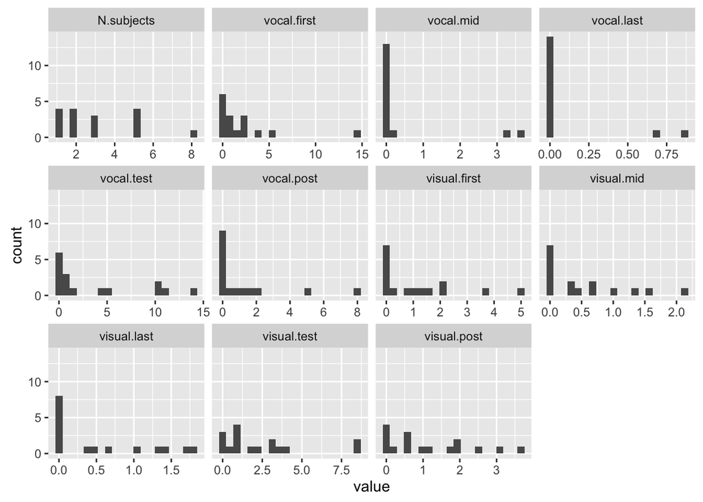

Data are diffuse and non-normal, will have to use non-parametric stats

```
## [1] "visual.first" "visual.mid"   "visual.last"  "visual.test"
## [5] "visual.post"
```

```
## [1] "vocal.first" "vocal.mid"   "vocal.last"  "vocal.test"  "vocal.post"
```

#### Visualizing the visual response data:

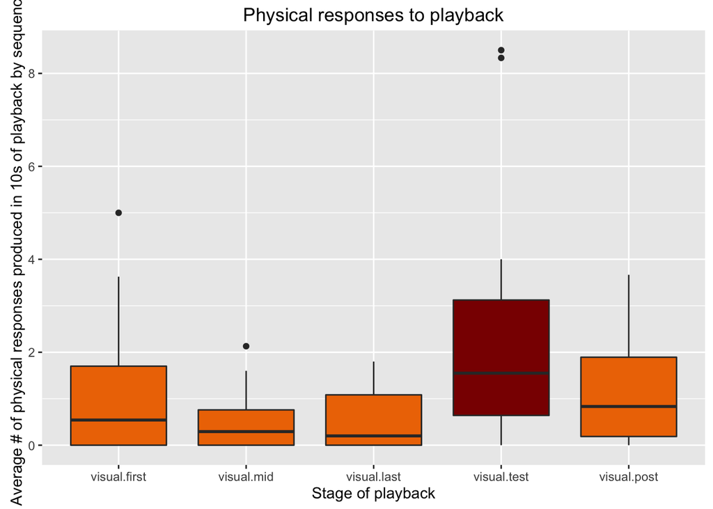

#### Visualizing the vocal response data

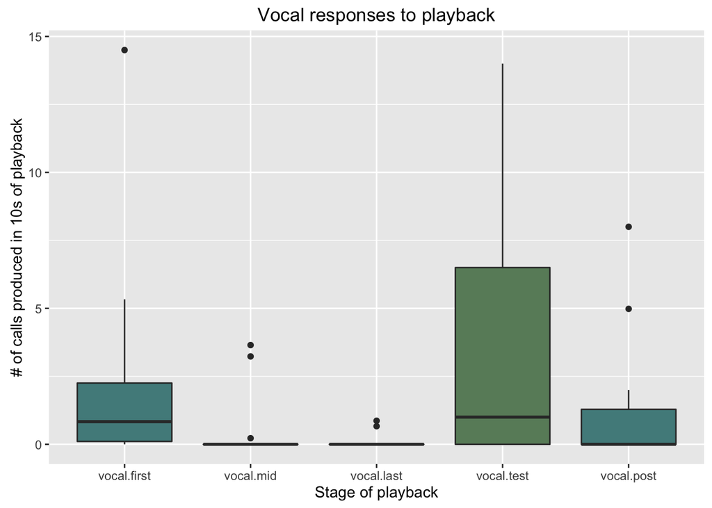

Carter et al. Averaged the response right before and right after the test calls, and compared that to the response during the test calls. This is a conservative approach (see text). This is what this looks like, using non-parametric stats: wilcoxon-signed rank test (because variables are not independent, but rather matched)

```
## [1] 1
```

```
## [1] 0
```

```
##
##  Wilcoxon signed rank test with continuity correction
##
## data:  gc_seq$vocal.test and gc_seq$habit_avg_voc
## V = 55, p-value = 0.002945
## alternative hypothesis: true location shift is greater than 0
```

```
## [1] 1.55
```

```
## [1] 0
```

```
##
##  Wilcoxon signed rank test with continuity correction
##
## data:  gc_seq$visual.test and gc_seq$habit_avg_vis
## V = 91, p-value = 0.0008308
## alternative hypothesis: true location shift is greater than 0
```

Vocal response: V = 55, p-value = 0.002945 (G.C. found T=49, N=8, P= 0.005)) Visual response: V = 91, p-value = 0.0008308 (G.C. found T=49, P= 0.003)

Values may be different because they were run in spss, is possible that the formula is a little different. Same general conclusions, though.

### Habituation

#### Friedman test of vocal responses:

```
##
##  Friedman rank sum test
##
## data:  value and variable and playback.sequence
## Friedman chi-squared = 21.8, df = 2, p-value = 1.846e-05
```

Friedman chi-squared = 21.8, df = 2, p-value = 1.846e-05

So, this test found that we can reject the null that all the variables came from the same distribution. Further pairwise post-hoc test will determine in which direction (if the bats decreased their response after the first 10s of playback)

```
## $Friedman.Test
##
##  Asymptotic General Symmetry Test
##
## data:  value by
##   variable (vocal.first, vocal.mid, vocal.last)
##   stratified by playback.sequence
## maxT = 4.2485, p-value = 5.764e-05
## alternative hypothesis: two.sided
##
##
## $PostHoc.Test
##
## vocal.mid - vocal.first  4.000491e-04
## vocal.last - vocal.first 6.075009e-05
## vocal.last - vocal.mid   8.956423e-01
```

```
## $Friedman.Test
##
##  Asymptotic General Symmetry Test
##
## data:  value by
##   variable (vocal.first, vocal.mid, vocal.last)
##   stratified by playback.sequence
## maxT = 4.2485, p-value = 7.251e-05
## alternative hypothesis: two.sided
##
##
## $PostHoc.Test
##
## vocal.mid - vocal.first  4.000491e-04
## vocal.last - vocal.first 6.075009e-05
## vocal.last - vocal.mid   8.956423e-01
```

So again, the first 10 seconds had a significantly greater response than the middle and the last 10 seconds, but the middle and last were not different (floor effects). The P-values for the overall test are similar, but not exactly the same.

#### Friedman test of visual responses:

```
##
##  Friedman rank sum test
##
## data:  value and variable and playback.sequence
## Friedman chi-squared = 4.85, df = 2, p-value = 0.08848
```

Friedman chi-squared = 4.85, df = 2, p-value = 0.08848 This test did not reject the null that the responses to the variables came from the same distribution. This is somewhat surprising, given the plots, but probably because of the low power of Friedman’s tests. No post-hocs are necessary. We cannot say that bats physically demonstrated habituation. It is possible that the playbacks were simply not played long enough for the physical response to decline. We can say that the bats habituated somewhat overall though, because of the decline in the vocal response.

## Is there a difference between the habituated response and the response to the changed stimulus?

#### (Do these vampires discriminate?)

Carter et al. averaged responses before and after the stimulus change, but it is more consistent with other literature to just compare the response before the stimulus change to the response during the stimulus change To test this, I need to do a wilcoxon-signed rank test, comparing visual and vocal responses to the last 10s of the first stimulus, and the 10 seconds of the second stimulus

#### Vocal response

```
##
##  Wilcoxon signed rank test with continuity correction
##
## data:  gc_seq$vocal.last and gc_seq$vocal.test
## V = 0, p-value = 0.002945
## alternative hypothesis: true location shift is less than 0
```

So, bats called significantly more to the new bat calls than they did to the habituated bat calls. (p-value = 0.002945) #### Visual response

```
##
##  Wilcoxon signed rank test with continuity correction
##
## data:  gc_seq$visual.last and gc_seq$visual.test
## V = 0, p-value = 0.0008281
## alternative hypothesis: true location shift is less than 0
```

Bats also physically responded significantly more to the new bat calls than the habituated ones. (p-value = 0.0008281)

Again, because these are significant, it isn’t necessary to compare habituated response to the response when the first stimulus was reintroduced (we already have evidence for discrimination).

This result is consistent with that of G.Carter et al.